# Data Science Capstone Week two milestone report

Takeshi Oda

2017/10/19

## Objective of this project

Objective of this project is to build word prediction application. The goal of our prediction is to calculate probability of next word under a specific sequence of words. For example, below sentences are given.

‘make me the’

Application must propose some words in a order of high probability.

smelliest  
happiest  
bluest  
saddest

In this report, we will apply exploratory data anlalysis on combined three english text files from blog, news and twitter. Exploratory data anslysis is aimed to show statistical pattern of occurrence in english word in large text data and create modeling strategy to build prediction application.

## Basic Statistics of three english documents

First of all, we will see number of rows and words in below three text files.

en_US.blogs.txt  
en_US.news.txt  
en_US.twitter.txt

```r
txt_stats <- function(fname) {
        f <- file(paste("datasources/",fname, sep = ""), encoding="UTF-8")

        line <- readLines(con=f, -1)
        line <- unique(line)

        #cat (fname , ':', length(line), 'lines\n')
        close(f)

        text <- paste(line, collapse = " ")
        myCorpus <- corpus(text)
        mat <- dfm(myCorpus, stem=TRUE, remove_punct=TRUE)
        mat <- t(mat)

        #convert matrix to data frame
        freq <- as.data.frame(mat)
        freq$feature <- rownames(freq)
        colnames(freq) <- c("cnt", "Word")

        #cat(fname, ':', nrow(freq), 'words\n')

        ret <- paste(fname, ':', length(line), ' lines,',nrow(freq),' words.', sep="")
        return (ret)
}

files <- c("en_US.blogs.txt","en_US.news.txt","en_US.twitter.txt")
lapply(files, txt_stats)
```

```
## [[1]]
## [1] "en_US.blogs.txt:899288 lines,315957 words."
##
## [[2]]
## [1] "en_US.news.txt:77259 lines,75286 words."
##
## [[3]]
## [1] "en_US.twitter.txt:2305923 lines,369873 words."
```

## Creating training and testing data set

Next, we will combine three text files into one big text file ‘en_US.all.txt’. and split it into training set and testing set.

Training set:training_en_US.all.txt  
Testing set:testing_en_US.all.txt

## Exloratory Analysis

We see top 20 words in training set ‘training_en_US.all.txt’. In addition, we will create histogram of word count and think about its distribution.

```r
hist_table <- function(h) {
        n <- length(h$counts)
        class_names <- NULL
        for(i in 1:n) {
                class_names[i] <- paste(h$breaks[i], "～", h$breaks[i+1])
        }
        frequency_table <- data.frame(class=class_names, frequency=h$counts)
        frequency_table
}
word_freq <- function (datasettype) {
        if (datasettype == "training") {

        }
        else if (datasettype == "testing") {

        }
        else {
                stop ("invalid argument")
        }

        fname = paste("tidydata/",datasettype, "_en_US.all.txt", sep ="")
        f <- file(fname, encoding="UTF-8")
        line <- readLines(con=f, -1)
        text <- paste(line, collapse = " ")


        myCorpus <- corpus(text)
        mat <- dfm(myCorpus, stem=TRUE, remove_punct=TRUE)
        mat <- t(mat)

        #convert matrix to data frame
        freq <- as.data.frame(mat)
        freq$feature <- rownames(freq)
        colnames(freq) <- c("cnt", "Word")

        freq <- freq[order(freq$cnt, decreasing=TRUE),]
        freq

}
freq <- word_freq("training")
cat('Top 20 frequent words\n')
```

```
## Top 20 frequent words
```

```r
head(freq,20)
```

```
##          cnt Word
## the  1406754  the
## and   812118  and
## to    794547   to
## a     675671    a
## of    653695   of
## i     550530    i
## in    451886   in
## it    380448   it
## that  358102 that
## is    317840   is
## for   272907  for
## with  215074 with
## you   213981  you
## on    207018   on
## was   206753  was
## my    191709   my
## this  188350 this
## be    183034   be
## have  174115 have
## as    167063   as
```

```r
summary(freq$cnt)
```

```
##      Min.   1st Qu.    Median      Mean   3rd Qu.      Max.
##       1.0       1.0       1.0     103.1       3.0 1407000.0
```

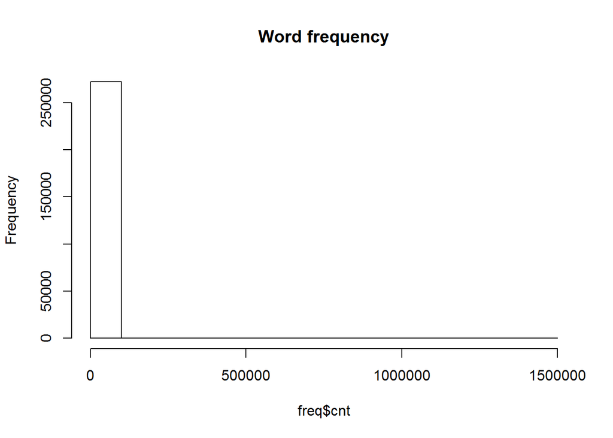

```r
h <- hist(freq$cnt, main="Word frequency")
```

```r
hist_table(h)
```

```
##                 class frequency
## 1          0 ～ 1e+05    271862
## 2      1e+05 ～ 2e+05        16
## 3      2e+05 ～ 3e+05         5
## 4      3e+05 ～ 4e+05         3
## 5      4e+05 ～ 5e+05         1
## 6      5e+05 ～ 6e+05         1
## 7      6e+05 ～ 7e+05         2
## 8      7e+05 ～ 8e+05         1
## 9      8e+05 ～ 9e+05         1
## 10     9e+05 ～ 1e+06         0
## 11   1e+06 ～ 1100000         0
## 12 1100000 ～ 1200000         0
## 13 1200000 ～ 1300000         0
## 14 1300000 ～ 1400000         0
## 15 1400000 ～ 1500000         1
```

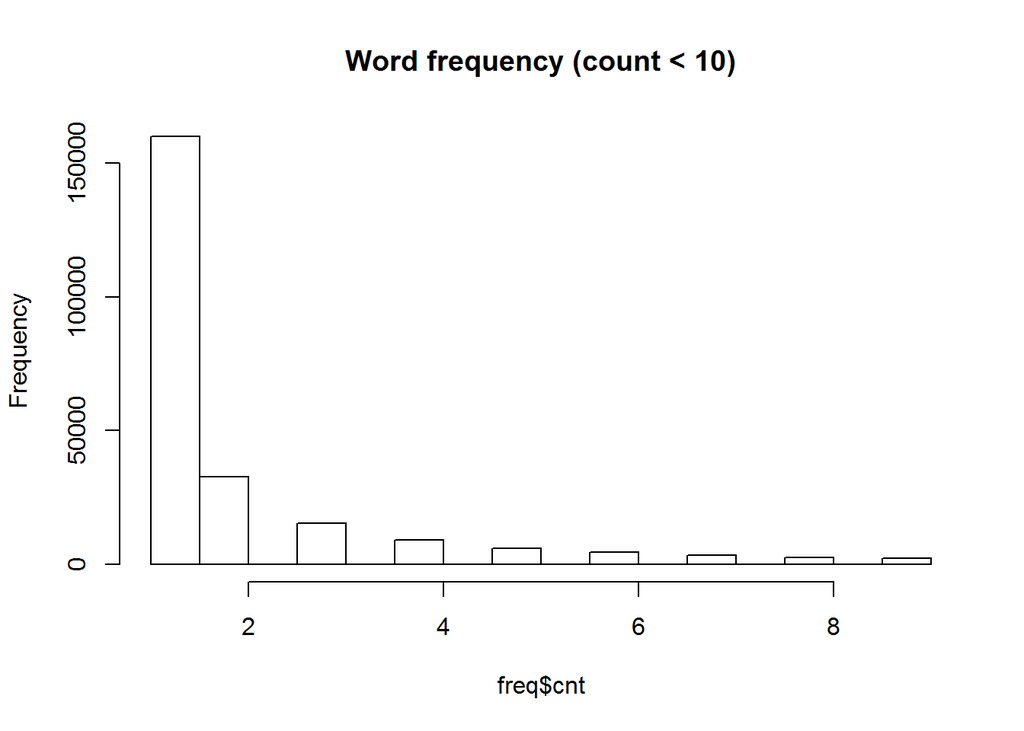

```r
freq <- freq[freq$cnt < 10,]
h <- hist(freq$cnt, main="Word frequency (count < 10)")
```

```r
hist_table(h)
```

```
##       class frequency
## 1  1 ～ 1.5    159750
## 2  1.5 ～ 2     32779
## 3  2 ～ 2.5         0
## 4  2.5 ～ 3     15460
## 5  3 ～ 3.5         0
## 6  3.5 ～ 4      9024
## 7  4 ～ 4.5         0
## 8  4.5 ～ 5      6094
## 9  5 ～ 5.5         0
## 10 5.5 ～ 6      4573
## 11 6 ～ 6.5         0
## 12 6.5 ～ 7      3572
## 13 7 ～ 7.5         0
## 14 7.5 ～ 8      2715
## 15 8 ～ 8.5         0
## 16 8.5 ～ 9      2377
```

**Above histogram shows that distribution of words in text data is very skewed. Large portion of words are occurred only once. We will exclude these rare words from prediction model to avoid overfitting.**

## Modeling approach

### Ngram Model

In natural language processing, ‘Ngram’ language model is commonly used to predict word in text. We introduce two models in Ngram.

(1)Bigram model  
Bigram model assumes that next word is dependent on previous one word. Estimated probability of next word is calculated from conditional probability.

Estimated probability to have a word w(i) after word w(i-1) is:

** P(w(i)|w(i-1)) = C(W(i-1) & W(i))/C(W(i-1))**

C(W(i-1)) is how many times a word is seen in the text. C(W(i-1) & W(i)) is how many times the sequence of two words are seen in the text.

(2)Trigram model  
Trigram model assumes next word is dependent on two preceding words.

Estimated probability to have a word w(i) after word w(i-2) and w(i-1) is:

** P(w(i)| w(i-2)& w(i-1) ) = C(W(i-2) & W(i-1) & W(i)) / C(W(i-2) & W(i-1) )**

By utilizing above two models, We will select a few words which have higest probability given one or two preceding word.

Generating and calculating probability in all combination of words leads to longer computation time and consumption of larger memory. Before building ngram model, we will see top 20 sequence of two words and histogram of bigram(Log of count of co-occurrence).

### Bigram

```r
ng <- function(datasettype, n) {
        if (datasettype == "training") {

        }
        else if (datasettype == "testing") {

        }
        else {
                stop ("invalid argument")
        }

        fname = paste("tidydata/",datasettype, "_en_US.all.txt", sep ="")

        f <- file(fname, encoding="UTF-8")
        line <- readLines(con=f, -1)
        text <- paste(line, collapse = " ")
        remove_list <- c("#+", "@+")
        tokensAll <- tokens(char_tolower(text),remove_punct = TRUE)
        tokensNoSpecialChar <- tokens_remove(tokensAll, remove_list, "regex")
        #tokensNoSpecialChar <- removeFeatures(tokensAll, remove_list)
        #tokensNoStopwords <- removeFeatures(tokensNoSpecialChar, stopwords("english"))
        tokensNgramNoStopwords <- tokens_ngrams(tokensNoSpecialChar,n)
        mat <- dfm(tokensNgramNoStopwords, verbose = FALSE)

        close(f)

        #transpose matrix
        mat <- t(mat)

        #convert matrix to data frame

        freq <- as.data.frame(mat)
        freq$feature <- rownames(freq)
        colnames(freq) <- c("cnt", "feature")

        freq <- freq[order(freq$cnt,decreasing = TRUE),]
        outfile <- paste("tidydata/ngram", n, "_", datasettype, ".csv",sep="")
        write.csv(freq, file=outfile, fileEncoding = "UTF-8", row.names = FALSE)

        freq
}

ngram2 <- ng("training",2)

summary(ngram2$cnt)
```

```
##     Min.  1st Qu.   Median     Mean  3rd Qu.     Max.
## 1.00e+00 1.00e+00 1.00e+00 4.86e+00 2.00e+00 1.41e+05
```

```r
head(ngram2,20)
```

```
##             cnt  feature
## of_the   141010   of_the
## in_the   116722   in_the
## to_the    64631   to_the
## on_the    57110   on_the
## to_be     50165    to_be
## for_the   44498  for_the
## and_the   43631  and_the
## at_the    36256   at_the
## u_2013    35574   u_2013
## i_was     35217    i_was
## and_i     35113    and_i
## it_was    35070   it_was
## it_is     34446    it_is
## in_a      34361     in_a
## i_have    34099   i_have
## is_a      33346     is_a
## with_the  33276 with_the
## i_am      30074     i_am
## from_the  28665 from_the
## that_i    27152   that_i
```

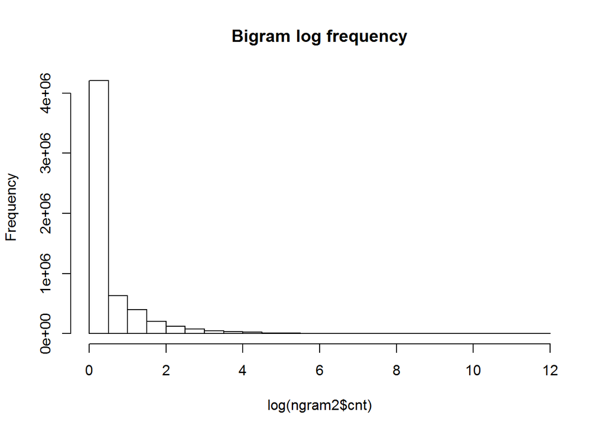

```r
hist(log(ngram2$cnt), main="Bigram log frequency")
```

```r
ngram3 <- ng("training",3)

summary(ngram3$cnt)
```

```
##      Min.   1st Qu.    Median      Mean   3rd Qu.      Max.
##     1.000     1.000     1.000     1.703     1.000 10890.000
```

```r
head(ngram3,20)
```

```
##                 cnt       feature
## one_of_the    10886    one_of_the
## a_lot_of       9241      a_lot_of
## to_be_a        5191       to_be_a
## as_well_as     5112    as_well_as
## it_was_a       5020      it_was_a
## some_of_the    5003   some_of_the
## the_end_of     4838    the_end_of
## out_of_the     4823    out_of_the
## be_able_to     4625    be_able_to
## a_couple_of    4338   a_couple_of
## i_want_to      4323     i_want_to
## this_is_a      3880     this_is_a
## the_fact_that  3878 the_fact_that
## the_rest_of    3774   the_rest_of
## going_to_be    3760   going_to_be
## i_have_to      3726     i_have_to
## part_of_the    3712   part_of_the
## there_is_a     3684    there_is_a
## i_have_a       3584      i_have_a
## it_is_a        3568       it_is_a
```

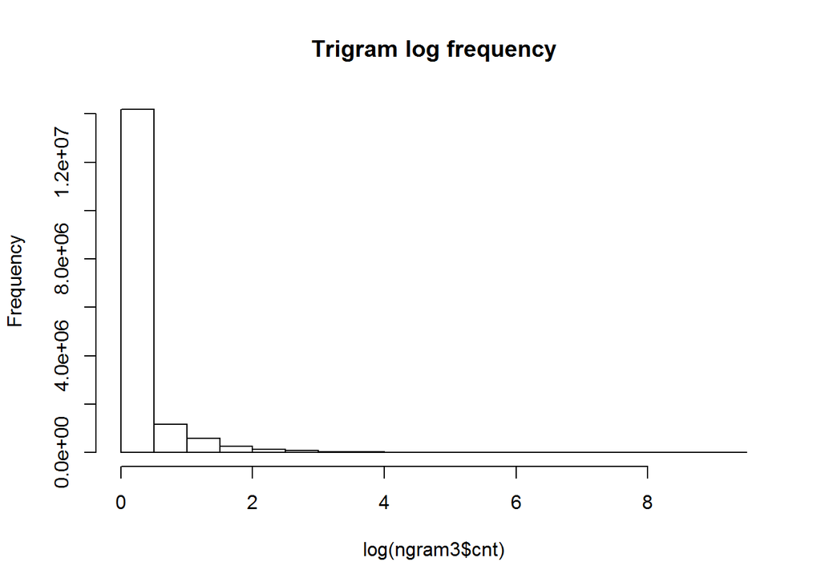

```r
hist(log(ngram3$cnt), main="Trigram log frequency")
```

## Goal of word prediction application

### (1)Algorithm

We will build prediction model by using ‘Back-off’ approach. To illustrate efficiency of this approach, we will see one example as follows.  
Suppose we predict which word comes after ‘I saw her on my’. We count how many possible words are actually found in training set with below conditions.

(1)Bigram  
Count how many words are found after ‘my’.  
(2)Trigram  
Count how many words are found after ‘on my’.

```r
ngram2_my <- subset(ngram2, grepl("my_",ngram2$feature))
ngram2_my <- ngram2_my[order(ngram2_my$cnt, decreasing=TRUE),]
ngram3_my <- subset(ngram3, grepl("on_my_",ngram3$feature))
ngram3_my <- ngram3_my[order(ngram3_my$cnt, decreasing=TRUE),]

cat ("Number of bigram my_:", nrow(ngram2_my))
```

```
## Number of bigram my_: 22171
```

```r
cat ("Number of trigram on_my_:", nrow(ngram3_my))
```

```
## Number of trigram on_my_: 2998
```

Above result shows that possible words after ‘my’ has 22171 while possible words after ‘on my’ has 2998. This means we might be able to predict next word with higher probability on trigram model than bigram model. Trigram is applied first to given sequence of words.Bigram model is used if there can not be found any matching word from trigram model.

### (2)Remove low quality information

As we discussed in this report, a lot of words or co-occurrences(bigram/trigram) are less reproducible and can be seen once or twice at most. To reduce workload and avoid overfitting ,We will ignore those rare observations from prediction model.